# DEseq analysis of Gat201-dependent gene expression

Liz Hughes and Edward Wallace

2022-05-01

# Summary

This document is an analysis of the Gat201 RNA-seq dataset, focusing on differences that depend only on Gat201 at later timepoints. This means that we treat the two WT strains as the same, and the two gat201∆ strains as the same.

This makes figure panels:

- count Gat201-dependent DEGs at each condition and timepoint
- volcano plot of Gat201-dependent DE at the most different timepoint (RPMI 4hours)
- heatmap of select Gat201-DEGs at each condition and timepoint
- compare Gat201-DEGs with ChIP-seq data by Venn diagram
- outputs Gat201-dependend differential expressed genes at RPMI 4hours

These are then combined into a multipanel figure, planned as figure 4 of the manuscript.

It also write differentially expressed gene data frames and genelists:

# Setup: load packages, load data, clean and prep data

## Load packages used for analysis

## Load H99 Gene information

```r
gene_info_df <-
  here::here("input_annotation",
             "H99_geneinfo_FungiDB59.txt") %>%
  readr::read_tsv(comment = "#")  %>%
  dplyr::rename(gene = GeneID, geneName = GeneName) %>%
  dplyr::mutate(geneName = dplyr::coalesce(geneName, gene))
```

## Load count data and remove unwanted parts of column names

```r
# note: we should insist that counts are loaded as integers
# and check the other data types
counts <-
  here::here("quantseqfwd_EH_050221", "counts.txt") %>%
  readr::read_tsv(comment = "#" #
                  #, col_types = paste0("cfiifi", rep("i", 56), collapse = "")
                  ) %>%
  dplyr::rename_with(str_remove_all, pattern = "_S[0-9]+_R1_001_aln.bam")
```

## Load sample sheet and format for DESeq2’s requirements: readxl::read_excel

Here we choose how the Strain labels behave by manipulating the factors. This creates a new variable `GAT201` whose levels are `del` and `WT`.

```r
Condition_Time_levels <- c("Y_0",
                           "R_30", "R_120", "R_240",
                           "RS_30", "RS_120", "RS_240")

## Condition_Time, for vertical printing
Condition_Time_levels_vprint <-
  c("\n0",
    "−\n30", "−\n120", "−\n240",
    "+\n30", "+\n120", "+\n240")

samplesheet <-
  here::here("input_experiment", "Gat201_samplesheet.xlsx") %>%
  readxl::read_excel() %>%
  magrittr::set_rownames(.$SampleID) %>%
  dplyr::mutate(GAT201 =
                  forcats::fct_collapse(Strain,
                                        "WT" = c("a","A"),
                                        "del" = c("B","M")) %>%
                  forcats::fct_relevel("del"),
                Timepoint = factor(Time),
                Condition_Time = factor(
                  paste(Condition, Time, sep = "_"),
                  levels = Condition_Time_levels
                )
  )
```

## Select counts

```r
counts_all <-
      dplyr::select(counts, samplesheet$SampleID) %>%
      magrittr::set_rownames(counts$Geneid)
```

# Differential gene expression analysis with DESEq2

## Run DESeq2 analysis dependent on Condition/Time and GAT201

This first uses the matrix of counts and the samplesheet information table to construct the DESeq2 data object, then immediately runs the analysis.

The design formula `~ Condition_Time + GAT201:Condition_Time - 1` ensures that every combination of Condition and Time has a coefficient, where we remove the intercept term by including `- 1`. Then the interaction term `GAT201:Condition_Time` gives the effect of `GAT201` separately at each combination of Condition and Time, which we are interested in.

```r
dds_all <- DESeqDataSetFromMatrix(
    countData = counts_all,
    colData = samplesheet,
    design = ~ Condition_Time + GAT201:Condition_Time - 1 ) %>%
  DESeq()

dds_all
```

```
## class: DESeqDataSet
## dim: 6795 56
## metadata(1): version
## assays(4): counts mu H cooks
## rownames(6795): CNAG_00002 CNAG_00003 ... CNAG_14001 CNAG_14002
## rowData names(70): baseMean baseVar ... deviance maxCooks
## colnames(56): 1 2 ... 55 56
## colData names(11): SampleID BioRep ... Condition_Time sizeFactor
```

```r
resultsNames(dds_all)
```

```
##  [1] "Condition_TimeY_0"             "Condition_TimeR_30"
##  [3] "Condition_TimeR_120"           "Condition_TimeR_240"
##  [5] "Condition_TimeRS_30"           "Condition_TimeRS_120"
##  [7] "Condition_TimeRS_240"          "Condition_TimeY_0.GAT201WT"
##  [9] "Condition_TimeR_30.GAT201WT"   "Condition_TimeR_120.GAT201WT"
## [11] "Condition_TimeR_240.GAT201WT"  "Condition_TimeRS_30.GAT201WT"
## [13] "Condition_TimeRS_120.GAT201WT" "Condition_TimeRS_240.GAT201WT"
```

## Select GAT201-dependent log2FC at each timepoint

```r
coefnames_GAT201 <- c("Condition_TimeY_0.GAT201WT", "Condition_TimeR_30.GAT201WT",
                      "Condition_TimeR_120.GAT201WT",  "Condition_TimeR_240.GAT201WT",
                      "Condition_TimeRS_30.GAT201WT",  "Condition_TimeRS_120.GAT201WT",
                      "Condition_TimeRS_240.GAT201WT")

# Create a tidy data frame that contains only the GAT201-dependent log2FC
# in a helpful format for plotting
deseq_df_CT_vsGAT201 <-
  biobroom::tidy.DESeqDataSet(dds_all) %>%
  dplyr::filter(term %in% coefnames_GAT201) %>%
  dplyr::mutate(Condition_Time = term %>%
                  stringr::str_remove("Condition_Time") %>%
                  stringr::str_remove(".GAT201WT") %>%
                  factor(levels = Condition_Time_levels)) %>%
  dplyr::left_join(gene_info_df,
                   by = "gene") %>%
  dplyr::select(Condition_Time,
                gene,
                geneName,
                baseMean,
                log2FC = estimate,
                stderror,
                padj = p.adjusted)

# check we retained all the levels
unique(deseq_df_CT_vsGAT201$Condition_Time)
```

```
## [1] RS_120 RS_240 RS_30  R_120  R_240  R_30   Y_0
## Levels: Y_0 R_30 R_120 R_240 RS_30 RS_120 RS_240
```

## Write deseq lists by timepoint to data frames.

```r
dplyr::filter(deseq_df_CT_vsGAT201,
              Condition_Time == "Y_0") %>%
  mutate_if(is.numeric, signif, digits = 5) %>%
  readr::write_tsv(file = here::here("results",
                                     "deseq_df_YPD_0_vsGAT201.txt"))

dplyr::filter(deseq_df_CT_vsGAT201,
              Condition_Time == "R_30") %>%
  mutate_if(is.numeric, signif, digits = 5) %>%
  readr::write_tsv(file = here::here("results",
                                     "deseq_df_RPMI_30_vsGAT201.txt"))

dplyr::filter(deseq_df_CT_vsGAT201,
              Condition_Time == "R_120") %>%
  mutate_if(is.numeric, signif, digits = 5) %>%
  readr::write_tsv(file = here::here("results",
                                     "deseq_df_RPMI_120_vsGAT201.txt"))

dplyr::filter(deseq_df_CT_vsGAT201,
              Condition_Time == "R_240") %>%
  mutate_if(is.numeric, signif, digits = 5) %>%
  readr::write_tsv(file = here::here("results",
                                     "deseq_df_RPMI_240_vsGAT201.txt"))

dplyr::filter(deseq_df_CT_vsGAT201,
              Condition_Time == "RS_30") %>%
  mutate_if(is.numeric, signif, digits = 5) %>%
  readr::write_tsv(file = here::here("results",
                                     "deseq_df_RPMISerum_30_vsGAT201.txt"))

dplyr::filter(deseq_df_CT_vsGAT201,
              Condition_Time == "RS_120") %>%
  mutate_if(is.numeric, signif, digits = 5) %>%
  readr::write_tsv(file = here::here("results",
                                     "deseq_df_RPMISerum_120_vsGAT201.txt"))

dplyr::filter(deseq_df_CT_vsGAT201,
              Condition_Time == "RS_240") %>%
  mutate_if(is.numeric, signif, digits = 5) %>%
  readr::write_tsv(file = here::here("results",
                                     "deseq_df_RPMISerum_240_vsGAT201.txt"))
```

## Count the number of DEGs up and down at each Condition and Time

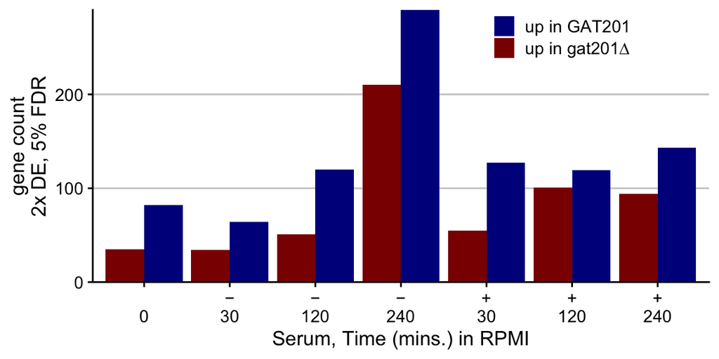

```r
countDEGs_CT_vsGAT201 <-
  deseq_df_CT_vsGAT201 %>%
  group_by(Condition_Time) %>%
  summarise(Up   = sum(log2FC > 1  & padj < 0.05, na.rm = TRUE),
            Down = sum(log2FC < -1 & padj < 0.05, na.rm = TRUE))

## prototype plot; not run but included as an example.
# ggplot(data = countDEGs_CT_vsGAT201,
#        aes(x = Condition_Time)) +
#   geom_col(aes(y = Up))

countDEGs_CT_vsGAT201_long <-
  countDEGs_CT_vsGAT201 %>%
  pivot_longer(cols = c(Up,Down),
               names_to = "Direction",
               values_to = "DEG_count")

barplot_countDEGs_CT_vsGAT201 <-
  ggplot(data = countDEGs_CT_vsGAT201_long,
         aes(x = Condition_Time, y = DEG_count, fill = Direction)) +
  geom_col(position = "dodge") +
  scale_fill_manual("GAT201 vs gat201∆",
                    breaks = c("Up", "Down"),
                    values = c("Up" = "darkblue",
                               "Down" = "darkred"),
                    labels = c("Up" = "up in GAT201",
                               "Down" = "up in gat201∆")) +
  scale_y_continuous("gene count\n2x DE, 5% FDR", expand = c(0,0)) +
  scale_x_discrete("Serum, Time (mins.) in RPMI",
                   breaks = Condition_Time_levels,
                   labels = Condition_Time_levels_vprint) +
  theme(panel.grid.major.x = element_blank(),
        legend.position = c(0.65, 0.9),
        legend.title = element_blank())

barplot_countDEGs_CT_vsGAT201
```

## Output the DEGs at YPD 0min

Write output to tsv files, in order of log2 fold-change.

```r
# Make data frames of DEGs up and down, arranged by log2FC
DEGdf_YPD_0_vsGAT201_up2x_FDR5 <-
  dplyr::filter(deseq_df_CT_vsGAT201,
                Condition_Time == "Y_0",
                log2FC > 1, padj < 0.05) %>%
  dplyr::arrange(desc(log2FC))

DEGdf_YPD_0_vsGAT201_down2x_FDR5 <-
  dplyr::filter(deseq_df_CT_vsGAT201,
                Condition_Time == "Y_0",
                log2FC < -1, padj < 0.05) %>%
  dplyr::arrange(log2FC)

writeLines(text = DEGdf_YPD_0_vsGAT201_up2x_FDR5 %>%
             pull(gene),
           con = here::here("results", "DEGids_YPD_0_vsGAT201_up2x_FDR5.txt"))

writeLines(text = DEGdf_YPD_0_vsGAT201_down2x_FDR5 %>%
             pull(gene),
           con = here::here("results", "DEGids_YPD_0_vsGAT201_down2x_FDR5.txt"))
```

## Volcano plot at RPMI 4h only

We are plotting only this Condition/Time because it has the most DEGs.

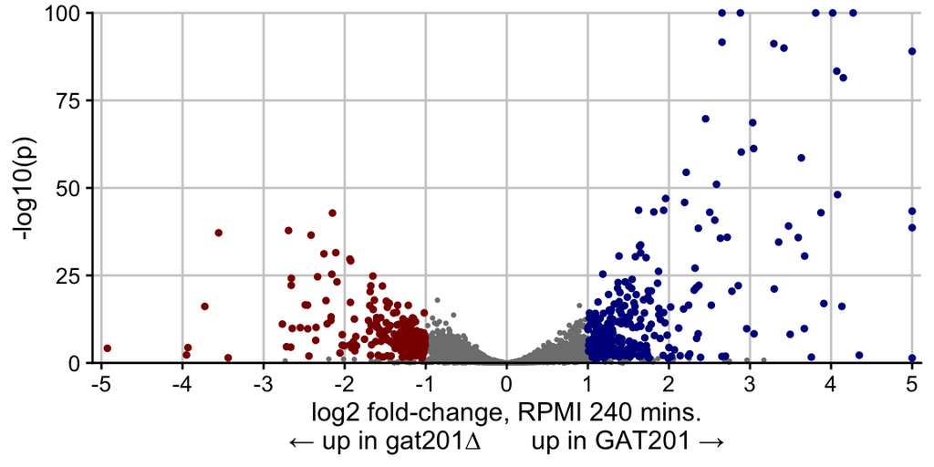

```r
# Make data frames of DEGs up and down, arranged by log2FC
DEGdf_RPMI_240_vsGAT201_up2x_FDR5 <-
  dplyr::filter(deseq_df_CT_vsGAT201,
                Condition_Time == "R_240",
                log2FC > 1, padj < 0.05) %>%
  dplyr::arrange(desc(log2FC))

DEGdf_RPMI_240_vsGAT201_down2x_FDR5 <-
  dplyr::filter(deseq_df_CT_vsGAT201,
                Condition_Time == "R_240",
                log2FC < -1, padj < 0.05) %>%
  dplyr::arrange(log2FC)

DEGs_of_interest <-
  c("GAT204", "LIV3", "BLP1", "PDR802", "HXT1", "FCY2")

DEGs_of_interest_df <-
  deseq_df_CT_vsGAT201 %>%
  dplyr::filter(geneName %in% DEGs_of_interest)

volcano_RPMI_240_vsGAT201 <-
  ggplot(data = dplyr::filter(deseq_df_CT_vsGAT201,
                              Condition_Time == "R_240"),
         aes(x = log2FC, y = -log10(padj)) ) +
  geom_point(size = 0.5, colour = "grey50") +
  geom_point(data = DEGdf_RPMI_240_vsGAT201_up2x_FDR5,
             size = 1, colour = "darkblue") +
  geom_point(data = DEGdf_RPMI_240_vsGAT201_down2x_FDR5,
             size = 1, colour = "darkred") +
  scale_y_continuous("-log10(p)",
                     limits = c(0,100), expand = c(0,0),
                     oob=scales::squish) +
  scale_x_continuous("log2 fold-change, RPMI 240 mins.\n← up in gat201∆       up in GAT201 →",
                     breaks = -5:5,
                     limits = c(-5,5), expand = c(0.01,0.01),
                     oob = scales::squish) +
  coord_cartesian(clip = "off") # +
  # geom_text_repel(data = dplyr::filter(DEGs_of_interest_df,
  #                             Condition_Time == "R_240"),
  #                 aes(label = geneName),
  #                 min.segment.length = 3, seed = 0,
  #                 colour = "darkblue")

volcano_RPMI_240_vsGAT201
```

## Output the DEGs at RPMI 4h only

Write output to tsv files, in order of log2 fold-change as calculated above.

```r
readr::write_tsv(x = DEGdf_RPMI_240_vsGAT201_up2x_FDR5 %>%
                   mutate_if(is.numeric, signif, digits = 5),
                 file = here::here("results",
                                   "DEGdf_RPMI_240_vsGAT201_up2x_FDR5.txt"))

readr::write_tsv(x = DEGdf_RPMI_240_vsGAT201_down2x_FDR5 %>%
                   mutate_if(is.numeric, signif, digits = 5),
                 file = here::here("results",
                                   "DEGdf_RPMI_240_vsGAT201_down2x_FDR5.txt"))
```

```r
writeLines(text = DEGdf_RPMI_240_vsGAT201_up2x_FDR5 %>%
             pull(gene),
           con = here::here("results", "DEGids_RPMI_240_vsGAT201_up2x_FDR5.txt"))

writeLines(text = DEGdf_RPMI_240_vsGAT201_down2x_FDR5 %>%
             pull(gene),
           con = here::here("results", "DEGids_RPMI_240_vsGAT201_down2x_FDR5.txt"))
```

## Check DEG lists at 4hrs for overlap plus/minus serum

Double-checking the overlap between GAT201-dependent DE genelists in RPMI with and without serum at 4h.

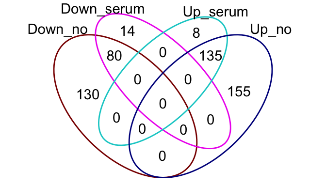

```r
vennplotdata_pmserum <-
  list(
    "Down_no" = dplyr::pull(DEGdf_RPMI_240_vsGAT201_down2x_FDR5, gene),
    "Down_serum" = dplyr::filter(deseq_df_CT_vsGAT201,
                                 Condition_Time == "RS_240",
                                 log2FC < -1, padj < 0.05) %>%
      dplyr::pull(gene),
    "Up_serum" = dplyr::filter(deseq_df_CT_vsGAT201,
                                 Condition_Time == "RS_240",
                                 log2FC > 1, padj < 0.05) %>%
      dplyr::pull(gene),
    "Up_no" = dplyr::pull(DEGdf_RPMI_240_vsGAT201_up2x_FDR5, gene)
  ) %>%
  RVenn::Venn() %>%
  ggVennDiagram::process_data()

ggplot() +
  geom_path(aes(x = X, y = Y, color = id, group = id),
            data = ggVennDiagram::venn_setedge(vennplotdata_pmserum),
            show.legend = FALSE) +
  geom_text(aes(X, Y, label = name),
               data = ggVennDiagram::venn_setlabel(vennplotdata_pmserum)) +
  geom_text(aes(X, Y, label = count),
            data = ggVennDiagram::venn_regionlabel(vennplotdata_pmserum)) +
  theme_void() +
  scale_colour_manual(values = c("darkred", "magenta2", "cyan3", "darkblue")) +
  coord_sf(clip = "off")
```

This confirms that in each direction about half the no-serum DEGs are same-direction DE in plus serum. Very few are DE plus-serum only. It supports the point that the direction of change is the same but the magnitude is different depending on serum.

## Reality-check by plotting fold change for a couple of known genes

Check that some marker genes are behaving as expected:

- GAT204 CNAG_06762, up in WT
- TSA1 CNAG_06917, up in WT
- ACT1 CNAG_00483, not really affected

This also defines the `plotheat_log2FC` function that we will use later.

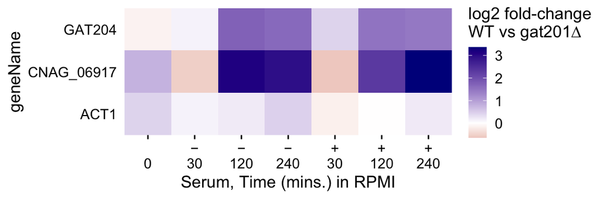

```r
plotheat_log2FC_gene <- function( genes = c("CNAG_06762", "CNAG_06917", "CNAG_00483"),
                             data = deseq_df_CT_vsGAT201) {
  ggplot( data = dplyr::filter(data,
                               gene %in% genes)
  ) +
    geom_tile(aes(x = Condition_Time, y = gene, fill = log2FC)) +
    scale_fill_gradient2("log2 fold-change\nWT vs gat201∆",
                         high = "darkblue", low = "darkred") +
    coord_cartesian(expand = c(0,0)) +
    theme(panel.grid.major = element_blank(),
          axis.line = element_blank(),
          axis.ticks.y = element_blank())
}

plotheat_log2FC_geneName <- function( geneNames = c("GAT204", "CNAG_06917", "ACT1"),
                                      data = deseq_df_CT_vsGAT201) {
  ggplot( data = dplyr::filter(data,
                               geneName %in% geneNames)
  ) +
    geom_tile(aes(x = Condition_Time, y = geneName, fill = log2FC)) +
    scale_fill_gradient2("log2 fold-change\nWT vs gat201∆",
                         high = "darkblue", low = "darkred") +
    scale_x_discrete("Serum, Time (mins.) in RPMI",
                     breaks = Condition_Time_levels,
                     labels = Condition_Time_levels_vprint) +
    coord_cartesian(expand = FALSE) +
    theme(panel.grid.major = element_blank(),
          axis.line = element_blank(),
          axis.ticks.y = element_blank())
}

plotheat_log2FC_geneName()
```

## Select genes that are DE dependent on GAT201 at any timepoint

This is a step towards making a heatmap of select differentially-expressed genes.

We use a cutoff of 2x difference, adjusted p-value 0.05.

Here we also plot in order of log2FC, averaged R_240 with RS_240.

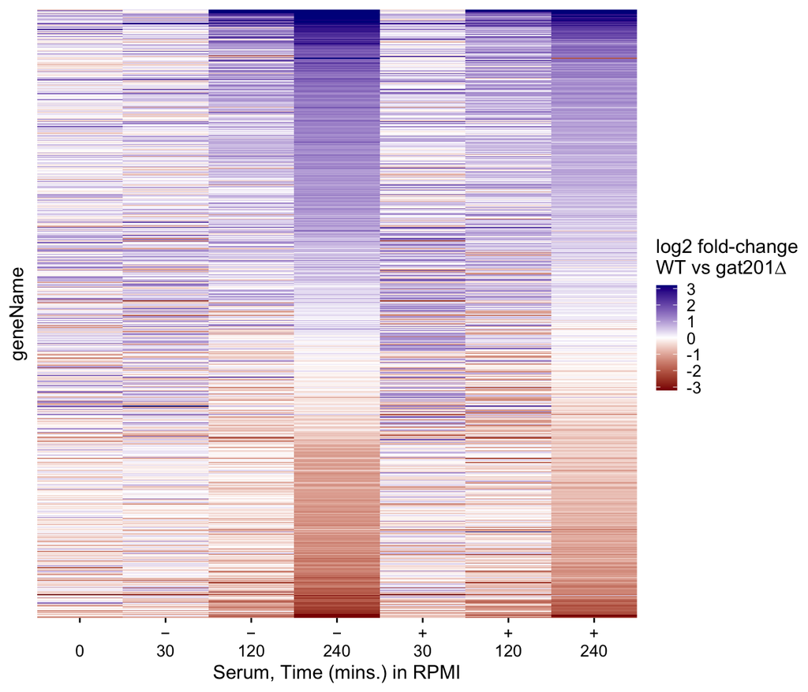

```r
DEGAT201_up_anytime2x <-
  deseq_df_CT_vsGAT201 %>%
  dplyr::filter(log2FC > 1, padj < 0.05)

DEGAT201_down_anytime2x <-
  deseq_df_CT_vsGAT201 %>%
  dplyr::filter(log2FC < -1, padj < 0.05)

DEGAT201_list_anytime2x <- c(unique(DEGAT201_up_anytime2x$geneName),
                             unique(DEGAT201_down_anytime2x$geneName))

# list genes arranged by log2FC at average of R_240 and RS_240
DEGAT201_list_anytime2x_arrange_240 <-
  deseq_df_CT_vsGAT201 %>%
  dplyr::filter(gene %in% DEGAT201_list_anytime2x,
                Condition_Time %in% c("R_240", "RS_240")) %>%
  group_by(gene, geneName) %>%
  dplyr::summarise(log2FC = mean(log2FC)) %>%
  dplyr::arrange(log2FC) %>%
  dplyr::pull(geneName)

# Create data frame with only those genes, ordered as above
# Note we use factor levels to create the ordering
deseq_df_CT_vsGAT201_anytime2x_arrange_240 <-
  deseq_df_CT_vsGAT201 %>%
  dplyr::filter(geneName %in% DEGAT201_list_anytime2x) %>%
  dplyr::mutate(geneName =
                  factor(geneName,
                         levels = DEGAT201_list_anytime2x_arrange_240))

heatmap_select_DEGAT201_anytime2x_240 <-
  plotheat_log2FC_geneName(geneNames = DEGAT201_list_anytime2x,
                           data =  deseq_df_CT_vsGAT201_anytime2x_arrange_240) +
  theme(axis.text.y = element_blank()) +
  scale_fill_gradient2("log2 fold-change\nWT vs gat201∆",
                       high = "darkblue", low = "darkred",
                       limits = c(-3.2, 3.2), oob = scales::squish)

heatmap_select_DEGAT201_anytime2x_240
```

## Select smaller list of genes that are very DE dependent on GAT201 at any timepoint

We use a more severe cutoff of 8x difference, adjusted p-value 0.05.

Here we again plot in order of log2FC averaged R_240 with RS_240.

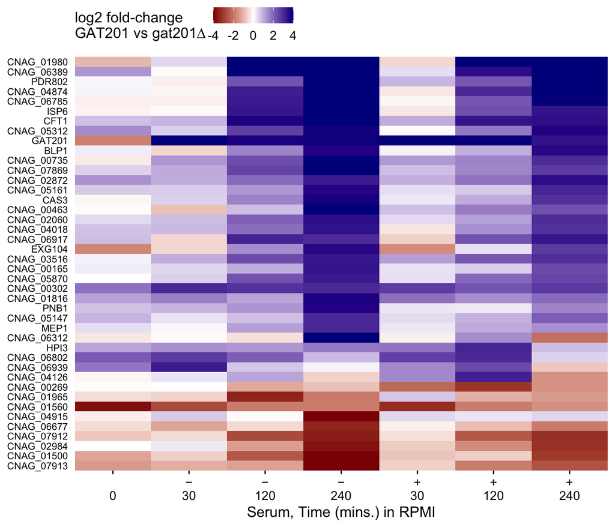

```r
DEGAT201_up_anytime8x <-
  deseq_df_CT_vsGAT201 %>%
  dplyr::filter(log2FC > 3, padj < 0.05)

DEGAT201_down_anytime8x <-
  deseq_df_CT_vsGAT201 %>%
  dplyr::filter(log2FC < -3, padj < 0.05)

DEGAT201_list_anytime8x <- c(unique(DEGAT201_up_anytime8x$geneName),
                             unique(DEGAT201_down_anytime8x$geneName))

# list genes arranged by log2FC at R_240
DEGAT201_list_anytime8x_arrange_240 <-
  deseq_df_CT_vsGAT201 %>%
  dplyr::filter(geneName %in% DEGAT201_list_anytime8x,
                Condition_Time %in% c("R_240", "RS_240")) %>%
  group_by(gene, geneName) %>%
  dplyr::summarise(log2FC = mean(log2FC)) %>%
  dplyr::arrange(log2FC) %>%
  dplyr::pull(geneName)

# Create data frame with only those genes, ordered as above
deseq_df_CT_vsGAT201_anytime8x_arrange_240 <-
  deseq_df_CT_vsGAT201 %>%
  dplyr::filter(geneName %in% DEGAT201_list_anytime8x) %>%
  dplyr::mutate(geneName =
                  factor(geneName,
                         levels = DEGAT201_list_anytime8x_arrange_240))

heatmap_select_DEGAT201_anytime8x_240 <-
  plotheat_log2FC_geneName(geneNames = DEGAT201_list_anytime8x,
                           data = deseq_df_CT_vsGAT201_anytime8x_arrange_240) +
  theme(axis.text.y = element_text(size = 8),
        axis.title.y = element_blank(),
        legend.position = "top") +
  scale_fill_gradient2("log2 fold-change\nGAT201 vs gat201∆",
                       high = "darkblue", low = "darkred",
                       limits = c(-4, 4), oob = scales::squish)

heatmap_select_DEGAT201_anytime8x_240
```

# Compare DEGs to ChIP-seq results from Homer et al

## Load ChIP-seq data

```r
ChIPtargets_Gat201 <-
  readxl::read_excel(here::here("data_external",
                                "Homer2016_TableS1_ChIPSeq.xls"),
                     sheet = "Gat201 ChIP-Seq")

ChIPtargets_Gat204 <-
  readxl::read_excel(here::here("data_external",
                                "Homer2016_TableS1_ChIPSeq.xls"),
                     sheet = "Gat204 ChIP-Seq")

ChIPtargets_Liv3 <-
  readxl::read_excel(here::here("data_external",
                                "Homer2016_TableS1_ChIPSeq.xls"),
                     sheet = "Liv3 ChIP-Seq")
```

## Venn diagram of DEGs at 4hr and Gat201 targets

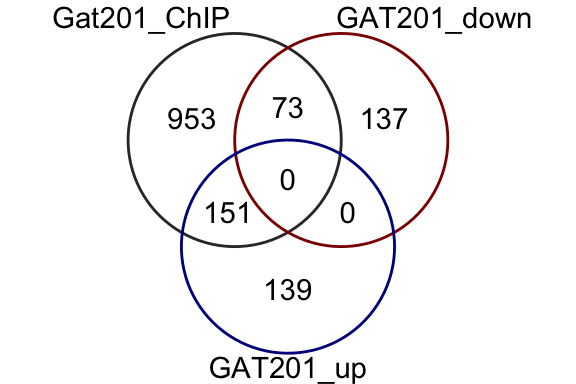

```r
vennplotdata_Gat201 <-
  list("Gat201_ChIP" = dplyr::pull(ChIPtargets_Gat201, CNAG),
       "GAT201_down" = dplyr::pull(DEGdf_RPMI_240_vsGAT201_down2x_FDR5, gene),
       "GAT201_up" = dplyr::pull(DEGdf_RPMI_240_vsGAT201_up2x_FDR5, gene)
  ) %>%
  RVenn::Venn() %>%
  ggVennDiagram::process_data()

venn_RPMI_240_vsGAT201_Gat201ChIP <-
  ggplot() +
  geom_path(aes(x = X, y = Y, color = id),
          data = venn_setedge(vennplotdata_Gat201), show.legend = FALSE) +
  geom_text(aes(x = X, y = Y, label = name),
               data = venn_setlabel(vennplotdata_Gat201)) +
  geom_text(aes(x = X, y = Y, label = count),
               data = venn_regionlabel(vennplotdata_Gat201)) +
  theme_void() +
  scale_colour_manual(values = c("grey20", "darkred", "darkblue")) +
  coord_sf(clip = "off")

venn_RPMI_240_vsGAT201_Gat201ChIP
```

Here the majority of GAT201_up genes are direct targets, p = 0.5206897.

This contrasts to a proportion of approximately 0.1732156 Gat201 targets in the genome.

That’s approximately a 3x enrichment.

## Venn diagram of DEGs at 4hr and Gat204 targets

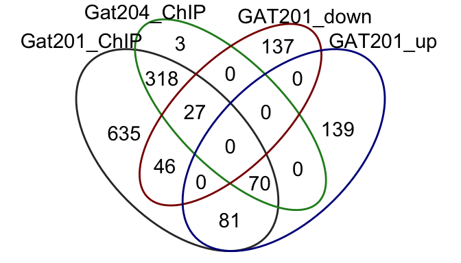

```r
vennplotdata_Gat204 <-
  list("Gat201_ChIP" = dplyr::pull(ChIPtargets_Gat201, CNAG),
       "Gat204_ChIP" = dplyr::pull(ChIPtargets_Gat204, CNAG),
       "GAT201_down" = dplyr::pull(DEGdf_RPMI_240_vsGAT201_down2x_FDR5, gene),
       "GAT201_up" = dplyr::pull(DEGdf_RPMI_240_vsGAT201_up2x_FDR5, gene)
  ) %>%
  RVenn::Venn() %>%
  ggVennDiagram::process_data()

venn_RPMI_240_vsGAT201_Gat204ChIP <-
  ggplot() +
  geom_path(aes(x = X, y = Y, color = id),
          data = ggVennDiagram::venn_setedge(vennplotdata_Gat204), show.legend = FALSE) +
  geom_text(aes(x = X, y = Y, label = name),
               data = ggVennDiagram::venn_setlabel(vennplotdata_Gat204)) +
  geom_text(aes(x = X, y = Y, label = count),
               data = ggVennDiagram::venn_regionlabel(vennplotdata_Gat204)) +
  theme_void() +
  scale_colour_manual(values = c("grey20", "forestgreen", "darkred", "darkblue")) +
  coord_sf(clip = "off")

venn_RPMI_240_vsGAT201_Gat204ChIP
```

This shows that all the Gat204 targets that are differentially regulated are also Gat201 targets. Also because 99% of Gat204 targets are Gat201 targets too.

## Venn diagram of DEGs at 4hr and Liv3 targets

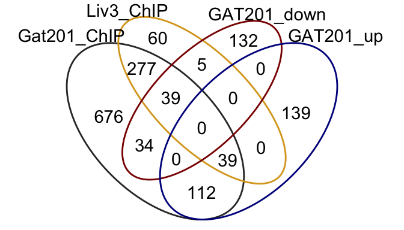

```r
vennplotdata_Liv3 <-
  list("Gat201_ChIP" = dplyr::pull(ChIPtargets_Gat201, CNAG),
       "Liv3_ChIP" = dplyr::pull(ChIPtargets_Liv3, CNAG),
       "GAT201_down" = dplyr::pull(DEGdf_RPMI_240_vsGAT201_down2x_FDR5, gene),
       "GAT201_up" = dplyr::pull(DEGdf_RPMI_240_vsGAT201_up2x_FDR5, gene)
  ) %>%
  RVenn::Venn() %>%
  ggVennDiagram::process_data()

venn_RPMI_240_vsGAT201_Liv3ChIP <-
  ggplot() +
  geom_path(aes(x = X, y = Y, color = id),
          data = ggVennDiagram::venn_setedge(vennplotdata_Liv3), show.legend = FALSE) +
  geom_text(aes(x = X, y = Y, label = name),
               data = ggVennDiagram::venn_setlabel(vennplotdata_Liv3)) +
  geom_text(aes(x = X, y = Y, label = count),
               data = ggVennDiagram::venn_regionlabel(vennplotdata_Liv3)) +
  theme_void() +
  scale_colour_manual(values = c("grey20", "goldenrod", "darkred", "darkblue")) +
  coord_sf(clip = "off")

venn_RPMI_240_vsGAT201_Liv3ChIP
```

Similarly, almost all the Liv3 targets that are differentially regulated are also Gat201 targets.

Collectively this argues that Gat201 is itself the major driver of differential gene expression on this timescale.

## Output intersected genelists

We recently showed that gat204∆ also derepresses growth in RPMI, like gat201∆. This suggests that there might be one or more shared targets of both GAT201 and GAT204 that contribute to the phenotype. Here we create and write out genelists:

- DEGids_RPMI_240_vsGAT201_up2x_FDR5_intersectGAT201ChIP.txt
- DEGids_RPMI_240_vsGAT201_up2x_FDR5_intersectGAT201ChIPGAT204ChIP.txt

```r
DEGids_RPMI_240_vsGAT201_up2x_FDR5_intersectGAT201ChIP <-
  dplyr::pull(ChIPtargets_Gat201, CNAG) %>%
  intersect(dplyr::pull(DEGdf_RPMI_240_vsGAT201_up2x_FDR5, gene)) %T>%
  write_lines(here::here("results",
                         "DEGids_RPMI_240_vsGAT201_up2x_FDR5_intersectGAT201ChIP.txt"))

DEGids_RPMI_240_vsGAT201_up2x_FDR5_intersectGAT201ChIPGAT204ChIP <-
  dplyr::pull(ChIPtargets_Gat201, CNAG) %>%
  intersect(dplyr::pull(ChIPtargets_Gat204, CNAG)) %>%
  intersect(dplyr::pull(DEGdf_RPMI_240_vsGAT201_up2x_FDR5, gene)) %T>%
  write_lines(here::here("results",
                         "DEGids_RPMI_240_vsGAT201_up2x_FDR5_intersectGAT201ChIPGAT204ChIP.txt"))

DEGids_RPMI_240_vsGAT201_down2x_FDR5_intersectGAT201ChIP <-
  dplyr::pull(ChIPtargets_Gat201, CNAG) %>%
  intersect(dplyr::pull(DEGdf_RPMI_240_vsGAT201_down2x_FDR5, gene)) %T>%
  write_lines(here::here("results",
                         "DEGids_RPMI_240_vsGAT201_down2x_FDR5_intersectGAT201ChIP.txt"))

DEGids_RPMI_240_vsGAT201_down2x_FDR5_intersectGAT201ChIPGAT204ChIP <-
  dplyr::pull(ChIPtargets_Gat201, CNAG) %>%
  intersect(dplyr::pull(ChIPtargets_Gat204, CNAG)) %>%
  intersect(dplyr::pull(DEGdf_RPMI_240_vsGAT201_down2x_FDR5, gene)) %T>%
  write_lines(here::here("results", "DEGids_RPMI_240_vsGAT201_down2x_FDR5_intersectGAT201ChIPGAT204ChIP.txt"))
```

# Multipanel Figure

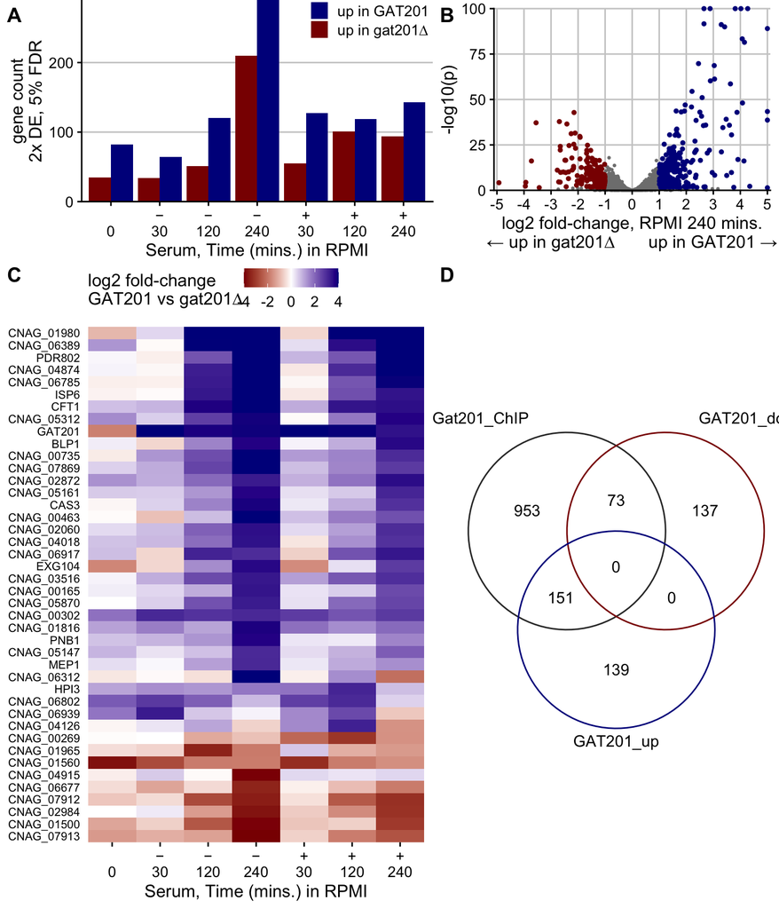

```r
figure_DESEQ_GAT201 <-
  plot_grid(
    barplot_countDEGs_CT_vsGAT201 +
      theme(plot.margin = unit(c(0,0,0,0.1),"in")),
    volcano_RPMI_240_vsGAT201,
    heatmap_select_DEGAT201_anytime8x_240,
    venn_RPMI_240_vsGAT201_Gat201ChIP  +
      theme(plot.margin = unit(c(0,0,0.1,0.2),"in")),
    # ggdraw() +
    #   draw_label("GO analysis",
    #              colour = "grey50", size = 18),
    ncol = 2,
    labels = "AUTO",
    rel_widths = c(1.25, 1),
    rel_heights = c(1, 2.5)
  )

figure_DESEQ_GAT201
```

```r
here::here("results","figure_DESEQ_GAT201.svg") %>%
  ggsave(plot = figure_DESEQ_GAT201, width = 7.5, height = 8.75)
```